# Week 9: Limited Dependent Variables Part 2

Samuel Rowe

10/19/2024

# Poisson, Negative Binominal Regression, Censored, Truncated, and Sample Selection

**Source: Wooldridge (2014), Long and Freese (2005)**

### Poisson Regression

**Lesson: We should use a count model when we have a Poisson distribution for the outcome of interest.**

Our coefficients are expected log counts so we need to transform our coefficients for interpretation.

We want to look at arrest data to see the number of times a man was arrested in 1986. There are 1,970 zeros out of 2,725 men in the sample and only eight observations are greater than 5. An OLS will not account for a count model but a Poisson distribution will.

1. narr86 - the number of times arrested in 1986
2. pcnv - proportion of prior arrest that lead to a conviction
3. avgsen - the average sentence served from prior convictions (in months)
4. tottime - months spent in prison since age 18 prior to 1986
5. ptime86 - months spent in prison in 1986
6. qemp86 - number of quarters that the person was legally employed in 1986
7. inc86 - income in 1986
8. Hispanic - Hispanic/Latino binary
9. Black - Black binary
10. ptime86 - months in prison during 1986

$$narr86_{i} = \beta_{0} + \beta_{1}
pcnv_{i} + \beta_{2} avgsen_{i} + \beta_{3} tottime_{i} + \beta_{4}
ptime86_{i} + \beta_{5} qemp86_{i} + \beta_{6} inc86_{i} + \beta_{7}
black_{i} + \beta_{8} hispan_{i} + \beta_{9} born60_{i} + u_{i}$$

#### OLS

```stata
use "/Users/Sam/Desktop/Econ 645/Data/Wooldridge/crime1.dta", clear
reg narr86 pcnv avgsen tottime ptime86 qemp86 inc86 black hispan born60
```

```
      Source |       SS           df       MS      Number of obs   =     2,725
-------------+----------------------------------   F(9, 2715)      =     23.57
       Model |  145.702778         9  16.1891976   Prob > F        =    0.0000
    Residual |  1864.64438     2,715  .686793509   R-squared       =    0.0725
-------------+----------------------------------   Adj R-squared   =    0.0694
       Total |  2010.34716     2,724  .738012906   Root MSE        =    .82873

------------------------------------------------------------------------------
      narr86 |      Coef.   Std. Err.      t    P>|t|     [95% Conf. Interval]
-------------+----------------------------------------------------------------
        pcnv |   -.131886   .0404037    -3.26   0.001    -.2111112   -.0526609
      avgsen |  -.0113316   .0122413    -0.93   0.355    -.0353348    .0126717
     tottime |   .0120693   .0094364     1.28   0.201     -.006434    .0305725
     ptime86 |  -.0408735    .008813    -4.64   0.000    -.0581544   -.0235925
      qemp86 |  -.0513099   .0144862    -3.54   0.000     -.079715   -.0229047
       inc86 |  -.0014617    .000343    -4.26   0.000    -.0021343   -.0007891
       black |   .3270097   .0454264     7.20   0.000     .2379359    .4160835
      hispan |   .1938094   .0397156     4.88   0.000     .1159335    .2716853
      born60 |   -.022465   .0332945    -0.67   0.500    -.0877502    .0428202
       _cons |    .576566   .0378945    15.22   0.000      .502261    .6508711
------------------------------------------------------------------------------
```

#### Poisson

Our coefficients are the change in expected log counts

```stata
use "/Users/Sam/Desktop/Econ 645/Data/Wooldridge/crime1.dta", clear
poisson narr86 pcnv avgsen tottime ptime86 qemp86 inc86 black hispan born60
```

```
Iteration 0:   log likelihood = -2249.0104
Iteration 1:   log likelihood = -2248.7614
Iteration 2:   log likelihood = -2248.7611
Iteration 3:   log likelihood = -2248.7611

Poisson regression                              Number of obs     =      2,725
                                                LR chi2(9)        =     386.32
                                                Prob > chi2       =     0.0000
Log likelihood = -2248.7611                     Pseudo R2         =     0.0791

------------------------------------------------------------------------------
      narr86 |      Coef.   Std. Err.      z    P>|z|     [95% Conf. Interval]
-------------+----------------------------------------------------------------
        pcnv |  -.4015713   .0849712    -4.73   0.000    -.5681117   -.2350308
      avgsen |  -.0237723    .019946    -1.19   0.233    -.0628658    .0153212
     tottime |   .0244904   .0147504     1.66   0.097    -.0044199    .0534006
     ptime86 |  -.0985584   .0206946    -4.76   0.000    -.1391192   -.0579977
      qemp86 |  -.0380187   .0290242    -1.31   0.190    -.0949051    .0188677
       inc86 |  -.0080807    .001041    -7.76   0.000     -.010121   -.0060404
       black |   .6608376   .0738342     8.95   0.000     .5161252      .80555
      hispan |   .4998133   .0739267     6.76   0.000     .3549196     .644707
      born60 |  -.0510286   .0640518    -0.80   0.426    -.1765678    .0745106
       _cons |  -.5995888   .0672501    -8.92   0.000    -.7313966    -.467781
------------------------------------------------------------------------------
```

**Test the Key assumption**

We need to test
$$E(y|x)=Var(y|x)$$

```stata
    estat gof
```

```
         Deviance goodness-of-fit =  2822.185
         Prob > chi2(2715)        =    0.0742

         Pearson goodness-of-fit  =   4118.08
         Prob > chi2(2715)        =    0.0000
```

### Factor Change Interpretation

```stata
display (exp(-.402*.01)-1)*100
```

```
-.40119306
```

A 1 percentage point increase in prior arrest decreases **expected** number of arrests by 0.4% A discrete change in a binary - the coefficient on Black

```stata
display (exp(0.6608)-1)*100
```

```
93.634079
```

We can use the command listcoef as well, where $e^\beta$ or $(e^\beta-1)*100$ depending upon the option called *percent*.

```stata
scc install listcoef
listcoef, help
listcoef, percent help
```

```
poisson (N=2725): Factor Change in Expected Count

 Observed SD: .85907678

------------------------------------------------------------------
  narr86 |      b         z     P>|z|    e^b    e^bStdX      SDofX
---------+--------------------------------------------------------
    pcnv |  -0.40157   -4.726   0.000   0.6693   0.8533     0.3952
  avgsen |  -0.02377   -1.192   0.233   0.9765   0.9200     3.5080
 tottime |   0.02449    1.660   0.097   1.0248   1.1194     4.6070
 ptime86 |  -0.09856   -4.763   0.000   0.9061   0.8251     1.9501
  qemp86 |  -0.03802   -1.310   0.190   0.9627   0.9406     1.6104
   inc86 |  -0.00808   -7.762   0.000   0.9920   0.5837    66.6272
   black |   0.66084    8.950   0.000   1.9364   1.2750     0.3677
  hispan |   0.49981    6.761   0.000   1.6484   1.2291     0.4127
  born60 |  -0.05103   -0.797   0.426   0.9503   0.9758     0.4808
------------------------------------------------------------------
       b = raw coefficient
       z = z-score for test of b=0
   P>|z| = p-value for z-test
     e^b = exp(b) = factor change in expected count for unit increase in X
 e^bStdX = exp(b*SD of X) = change in expected count for SD increase in X
   SDofX = standard deviation of X


poisson (N=2725): Percentage Change in Expected Count

 Observed SD: .85907678

------------------------------------------------------------------
  narr86 |      b         z     P>|z|      %      %StdX      SDofX
---------+--------------------------------------------------------
    pcnv |  -0.40157   -4.726   0.000    -33.1    -14.7     0.3952
  avgsen |  -0.02377   -1.192   0.233     -2.3     -8.0     3.5080
 tottime |   0.02449    1.660   0.097      2.5     11.9     4.6070
 ptime86 |  -0.09856   -4.763   0.000     -9.4    -17.5     1.9501
  qemp86 |  -0.03802   -1.310   0.190     -3.7     -5.9     1.6104
   inc86 |  -0.00808   -7.762   0.000     -0.8    -41.6    66.6272
   black |   0.66084    8.950   0.000     93.6     27.5     0.3677
  hispan |   0.49981    6.761   0.000     64.8     22.9     0.4127
  born60 |  -0.05103   -0.797   0.426     -5.0     -2.4     0.4808
------------------------------------------------------------------
       b = raw coefficient
       z = z-score for test of b=0
   P>|z| = p-value for z-test
       % = percent change in expected count for unit increase in X
   %StdX = percent change in expected count for SD increase in X
   SDofX = standard deviation of X
```

### Marginal Effects

**Average Marginal Effects**

```stata
use "/Users/Sam/Desktop/Econ 645/Data/Wooldridge/crime1.dta", clear
quietly poisson narr86 pcnv avgsen tottime ptime86 qemp86 inc86 black hispan born60
margins, dydx(*)
```

```
Average marginal effects                        Number of obs     =      2,725
Model VCE    : OIM

Expression   : Predicted number of events, predict()
dy/dx w.r.t. : pcnv avgsen tottime ptime86 qemp86 inc86 black hispan born60

------------------------------------------------------------------------------
             |            Delta-method
             |      dy/dx   Std. Err.      z    P>|z|     [95% Conf. Interval]
-------------+----------------------------------------------------------------
        pcnv |  -.1623969   .0347091    -4.68   0.000    -.2304256   -.0943682
      avgsen |  -.0096136   .0080714    -1.19   0.234    -.0254333    .0062061
     tottime |    .009904   .0059726     1.66   0.097     -.001802      .02161
     ptime86 |  -.0398574   .0084547    -4.71   0.000    -.0564283   -.0232865
      qemp86 |  -.0153749   .0117466    -1.31   0.191    -.0383979    .0076481
       inc86 |  -.0032679   .0004323    -7.56   0.000    -.0041152   -.0024205
       black |   .2672451   .0309251     8.64   0.000     .2066331    .3278571
      hispan |   .2021263     .03051     6.62   0.000     .1423279    .2619248
      born60 |  -.0206361   .0259102    -0.80   0.426    -.0714193     .030147
------------------------------------------------------------------------------
```

**Interpretation:** The marginal change in a continuous variable depends on the expected value of y given x, so we have to specify x with atmeans or average marginal effects

**Note:** be careful with the change in percentage points for pcnv, we want a 1 percentage point or 10 percentage point change not a change of 1.

### Negative Binomial Regression Model

```stata
use "/Users/Sam/Desktop/Econ 645/Data/Wooldridge/crime1.dta", clear
nbreg narr86 pcnv avgsen tottime ptime86 qemp86 inc86 black hispan born60
```

```
Fitting Poisson model:

Iteration 0:   log likelihood = -2249.0104
Iteration 1:   log likelihood = -2248.7614
Iteration 2:   log likelihood = -2248.7611
Iteration 3:   log likelihood = -2248.7611

Fitting constant-only model:

Iteration 0:   log likelihood = -2297.3847
Iteration 1:   log likelihood = -2291.4767
Iteration 2:   log likelihood = -2290.6926
Iteration 3:   log likelihood = -2290.6903
Iteration 4:   log likelihood = -2290.6903

Fitting full model:

Iteration 0:   log likelihood = -2181.2355
Iteration 1:   log likelihood = -2158.2716
Iteration 2:   log likelihood = -2157.6284
Iteration 3:   log likelihood =  -2157.628
Iteration 4:   log likelihood =  -2157.628

Negative binomial regression                    Number of obs     =      2,725
                                                LR chi2(9)        =     266.12
Dispersion     = mean                           Prob > chi2       =     0.0000
Log likelihood =  -2157.628                     Pseudo R2         =     0.0581

------------------------------------------------------------------------------
      narr86 |      Coef.   Std. Err.      z    P>|z|     [95% Conf. Interval]
-------------+----------------------------------------------------------------
        pcnv |  -.4770963   .1033295    -4.62   0.000    -.6796183   -.2745743
      avgsen |  -.0173385   .0261171    -0.66   0.507    -.0685272    .0338501
     tottime |   .0197394   .0192325     1.03   0.305    -.0179557    .0574344
     ptime86 |  -.1073997    .025074    -4.28   0.000    -.1565439   -.0582555
      qemp86 |  -.0504884   .0351857    -1.43   0.151    -.1194511    .0184743
       inc86 |  -.0077126   .0011465    -6.73   0.000    -.0099596   -.0054656
       black |   .6560406   .0923594     7.10   0.000     .4750195    .8370617
      hispan |   .5048465   .0895663     5.64   0.000     .3292998    .6803932
      born60 |   -.046412   .0776384    -0.60   0.550    -.1985804    .1057564
       _cons |  -.5637368   .0827121    -6.82   0.000    -.7258495   -.4016242
-------------+----------------------------------------------------------------
    /lnalpha |  -.0738912   .1177617                     -.3046999    .1569175
-------------+----------------------------------------------------------------
       alpha |   .9287728   .1093739                      .7373446    1.169899
------------------------------------------------------------------------------
LR test of alpha=0: chibar2(01) = 182.27               Prob >= chibar2 = 0.000
```

First, our coefficients are the change in expected log counts, so we need some transformations to provide interpretations. Second, our test for over dispersion can be seen at the bottom of our NBRM output with the LR test of alpha=0

We can use listcoef in ssc to for a different interpretation with listcoef command:

```stata
listcoef, percent help
listcoef, help
```

```
nbreg (N=2725): Percentage Change in Expected Count

 Observed SD: .85907678

------------------------------------------------------------------
  narr86 |      b         z     P>|z|      %      %StdX      SDofX
---------+--------------------------------------------------------
    pcnv |  -0.47710   -4.617   0.000    -37.9    -17.2     0.3952
  avgsen |  -0.01734   -0.664   0.507     -1.7     -5.9     3.5080
 tottime |   0.01974    1.026   0.305      2.0      9.5     4.6070
 ptime86 |  -0.10740   -4.283   0.000    -10.2    -18.9     1.9501
  qemp86 |  -0.05049   -1.435   0.151     -4.9     -7.8     1.6104
   inc86 |  -0.00771   -6.727   0.000     -0.8    -40.2    66.6272
   black |   0.65604    7.103   0.000     92.7     27.3     0.3677
  hispan |   0.50485    5.637   0.000     65.7     23.2     0.4127
  born60 |  -0.04641   -0.598   0.550     -4.5     -2.2     0.4808
---------+--------------------------------------------------------
ln alpha |  -0.07389   -0.627
------------------------------------------------------------------
       b = raw coefficient
       z = z-score for test of b=0
   P>|z| = p-value for z-test
       % = percent change in expected count for unit increase in X
   %StdX = percent change in expected count for SD increase in X
   SDofX = standard deviation of X


nbreg (N=2725): Factor Change in Expected Count

 Observed SD: .85907678

------------------------------------------------------------------
  narr86 |      b         z     P>|z|    e^b    e^bStdX      SDofX
---------+--------------------------------------------------------
    pcnv |  -0.47710   -4.617   0.000   0.6206   0.8282     0.3952
  avgsen |  -0.01734   -0.664   0.507   0.9828   0.9410     3.5080
 tottime |   0.01974    1.026   0.305   1.0199   1.0952     4.6070
 ptime86 |  -0.10740   -4.283   0.000   0.8982   0.8110     1.9501
  qemp86 |  -0.05049   -1.435   0.151   0.9508   0.9219     1.6104
   inc86 |  -0.00771   -6.727   0.000   0.9923   0.5982    66.6272
   black |   0.65604    7.103   0.000   1.9271   1.2728     0.3677
  hispan |   0.50485    5.637   0.000   1.6567   1.2316     0.4127
  born60 |  -0.04641   -0.598   0.550   0.9546   0.9779     0.4808
---------+--------------------------------------------------------
ln alpha |  -0.07389   -0.627
------------------------------------------------------------------
       b = raw coefficient
       z = z-score for test of b=0
   P>|z| = p-value for z-test
     e^b = exp(b) = factor change in expected count for unit increase in X
 e^bStdX = exp(b*SD of X) = change in expected count for SD increase in X
   SDofX = standard deviation of X
```

**Proportion of prior arrest that lead to a conviction**

```stata
    display exp(-.4771*.1)-1
```

```
-.04658976
```

**Interpretation** A 10 percentage point increase in proportion of prior arrests that lead to conviction decrease the expected number of arrests by 4.7% holding all others constant.

```stata
display (exp(0.01974)-1)
```

```
.01993612
```

**Interpretation** A 1 month increase in total time served in prision from prior convictions before 1986 increases the expected number of arrests holding all others constant.

**Compare Poisson and Negative Binominal Regression Models**

```stata
est clear
eststo PRM: quietly poisson narr86 pcnv avgsen tottime ptime86 qemp86 inc86 black hispan born60
eststo NBRM: quietly nbreg narr86 pcnv avgsen tottime ptime86 qemp86 inc86 black hispan born60
esttab, mtitle
```

```
                      (1)             (2)
                      PRM            NBRM
--------------------------------------------
narr86
pcnv               -0.402***       -0.477***
                  (-4.73)         (-4.62)

avgsen            -0.0238         -0.0173
                  (-1.19)         (-0.66)

tottime            0.0245          0.0197
                   (1.66)          (1.03)

ptime86           -0.0986***       -0.107***
                  (-4.76)         (-4.28)

qemp86            -0.0380         -0.0505
                  (-1.31)         (-1.43)

inc86            -0.00808***     -0.00771***
                  (-7.76)         (-6.73)

black               0.661***        0.656***
                   (8.95)          (7.10)

hispan              0.500***        0.505***
                   (6.76)          (5.64)

born60            -0.0510         -0.0464
                  (-0.80)         (-0.60)

_cons              -0.600***       -0.564***
                  (-8.92)         (-6.82)
--------------------------------------------
lnalpha
_cons                             -0.0739
                                  (-0.63)
--------------------------------------------
N                    2725            2725
--------------------------------------------
t statistics in parentheses
* p<0.05, ** p<0.01, *** p<0.001
```

### Marginal Effects for NBRM

The interpretation is similar to Poisson. The marginal change in a continuous variable depends on the expected value of y given x, so we have to specify x with atmeans or average marginal effects

```stata
use "/Users/Sam/Desktop/Econ 645/Data/Wooldridge/crime1.dta", clear
quietly nbreg narr86 pcnv avgsen tottime ptime86 qemp86 inc86 black hispan born60
margins, dydx(*)
```

```
Average marginal effects                        Number of obs     =      2,725
Model VCE    : OIM

Expression   : Predicted number of events, predict()
dy/dx w.r.t. : pcnv avgsen tottime ptime86 qemp86 inc86 black hispan born60

------------------------------------------------------------------------------
             |            Delta-method
             |      dy/dx   Std. Err.      z    P>|z|     [95% Conf. Interval]
-------------+----------------------------------------------------------------
        pcnv |  -.1933482   .0429858    -4.50   0.000    -.2775988   -.1090976
      avgsen |  -.0070266    .010587    -0.66   0.507    -.0277767    .0137235
     tottime |   .0079996   .0078006     1.03   0.305    -.0072894    .0232886
     ptime86 |  -.0435248   .0103794    -4.19   0.000    -.0638682   -.0231815
      qemp86 |  -.0204609   .0143136    -1.43   0.153    -.0485151    .0075932
       inc86 |  -.0031256   .0004821    -6.48   0.000    -.0040705   -.0021807
       black |   .2658672   .0395274     6.73   0.000     .1883949    .3433395
      hispan |   .2045942   .0375363     5.45   0.000     .1310244    .2781641
      born60 |  -.0188089   .0314753    -0.60   0.550    -.0804994    .0428815
------------------------------------------------------------------------------
```

### Censored Regression Model - Right-Censoring

**Lesson: We can use a Tobit estimator for right-censored model**

We need to summarize the dependent variable to see the right-censored value. We know that weekly earnings in the Current Population Survey are top-coded or right-censored at $2884.61. This may bias our estimate, so we’ll compare a OLS model and a Tobit model for right-censored data. Remember a Tobit estimator for a censored model is different from a corner solution.

```
                  Weekly Earnings: pternwa
-------------------------------------------------------------
      Percentiles      Smallest
 1%           70              0
 5%          225              0
10%          360              0       Obs              10,666
25%          656              0       Sum of Wgt.      10,666

50%         1000                      Mean           1230.474
                        Largest       Std. Dev.      788.1457
75%         1680        2884.61
90%       2692.3        2884.61       Variance       621173.7
95%      2884.61        2884.61       Skewness       .7779644
99%      2884.61        2884.61       Kurtosis       2.648218

(bin=40, start=0, width=72.11525)

(file /Users/Sam/Desktop/Econ 645/R Markdown/week9_histogram_earnings.png written in PNG format)
```

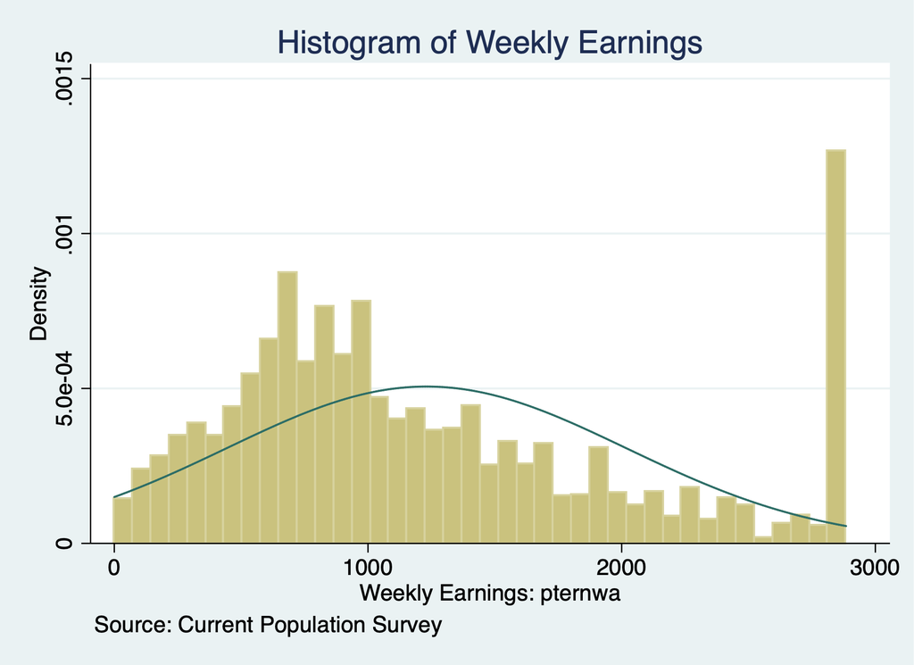

Histogram of Earnings

```stata
use "/Users/Sam/Desktop/Econ 645/Data/CPS/jan2024.dta", clear
sum earnings if prerelg==1, detail
histogram earnings if prerelg==1, normal title(Histogram of Weekly Earnings) caption("Source: Current Population Survey")
graph export "/Users/Sam/Desktop/Econ 645/R Markdown/week9_histogram_earnings.png", replace
```

Let us take a look at the natural log of earnings

```
               Natural Log of Weekly Earnings
-------------------------------------------------------------
      Percentiles      Smallest
 1%     4.356709      -3.506558
 5%     5.420535      -3.506558
10%     5.886104      -3.506558       Obs              10,652
25%      6.49224         .48858       Sum of Wgt.      10,652

50%     6.907755                      Mean            6.86502
                        Largest       Std. Dev.      .8181897
75%     7.426549       7.967145
90%     7.898151       7.967145       Variance       .6694343
95%     7.967145       7.967145       Skewness      -1.791008
99%     7.967145       7.967145       Kurtosis       13.92768

(bin=40, start=-3.5065579, width=.28684257)

(file /Users/Sam/Desktop/Econ 645/R Markdown/week9_histogram_lnearnings.png written in PNG format)
```

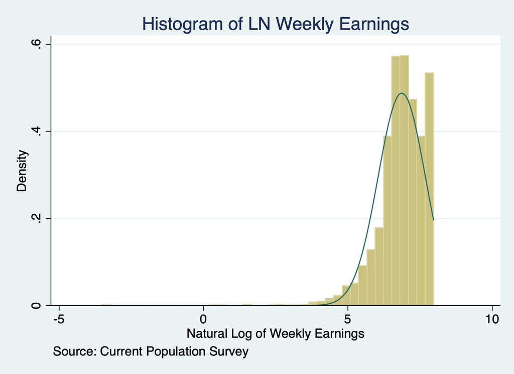

```stata
use "/Users/Sam/Desktop/Econ 645/Data/CPS/jan2024.dta", clear
sum lnearnings, detail
histogram lnearnings if prerelg==1, normal title(Histogram of LN Weekly Earnings) caption("Source: Current Population Survey")
graph export "/Users/Sam/Desktop/Econ 645/R Markdown/week9_histogram_lnearnings.png", replace
```

We’ll estimate the following Mincer Equation.
$$ln(wwages_{i})=\beta_{0}
+ \beta_{1} edu_{i} + \beta_{2} exp + \beta_{3} exp^2 \beta_{4}
marital_{i} + \beta_{5} veteran_{i} + \beta_{6} union_{i} + \beta_{7}
female_{i} + \beta_{8} race_{i} + u_{i}$$
We’ll need to use the option, *ul(right-censored-value)* with our Tobit estimator.

```stata
est clear
eststo OLS: quietly reg lnearnings i.edu exp expsq i.marital i.veteran i.union i.female i.race
eststo Tobit: quietly tobit lnearnings i.edu exp expsq i.marital i.veteran i.union i.female i.race, ul(`maxval')

esttab OLS Tobit, drop(0.* 1.race* 1.mar* 1.edu) mtitle("OLS" "Tobit")
```

[output not shown]

[output cut: 54 more lines]

```

7.race_eth~y       0.0549          0.0553
                   (0.73)          (0.69)

_cons               5.813***        5.817***
                  (69.47)         (64.82)
--------------------------------------------
sigma
_cons                               0.714***
                                 (137.00)
--------------------------------------------
N                   10568           10568
--------------------------------------------
t statistics in parentheses
* p<0.05, ** p<0.01, *** p<0.001
```

**Interpretation** A very similar interpretation to OLS, but we need normality and homoskedasticity for unbiased estimator. We can use a log-linear interpretation without a scaling factor, so the returns to education would only require $(e^\beta -1)*100$ interpretation.

### Censored Regression Model - Duration analysis

**Lesson: We can look at a censored data for duration analysis similar to Wooldridge’s example.**

This differs from a top-coded data, which we can use a Tobit analysis that we just saw.

We can look at the duration of time in months between an arrests for inmates in a North Carolina prison after being released from prison. We want to evaluate a work program to see if it is effective in increasing duration before recidivism occurs.

**Note**: 893 inmates have not been arrested during the period they were followed These observations are censored. The censoring times differed among inmates ranging from 70 to 81 months.

Our dependent variable duration (time in months) is transformed by natural logarithm. We have a bunch of observations that recidivate between 70 and 81 months.

```stata
use "/Users/Sam/Desktop/Econ 645/Data/Wooldridge/recid.dta", clear
tab durat
```

[output not shown]

We have a bunch of observations that are censored after 69 months (but not all)

```stata
use "/Users/Sam/Desktop/Econ 645/Data/Wooldridge/recid.dta", clear
tab durat cens
```

```
           |         cens
     durat |         0          1 |     Total
-----------+----------------------+----------
         1 |         8          0 |         8
         2 |        15          0 |        15
         3 |        14          0 |        14
         4 |        13          0 |        13
         5 |        16          0 |        16
         6 |        18          0 |        18
         7 |        18          0 |        18
         8 |        16          0 |        16
         9 |        18          0 |        18
        10 |        22          0 |        22
        11 |        11          0 |        11
        12 |        14          0 |        14
```

[output cut: 70 more lines]

We’ll use the stset command and set failure at cens==0. We’ll use the *stset* command to time set survival.

```stata
use "/Users/Sam/Desktop/Econ 645/Data/Wooldridge/recid.dta", clear
stset ldurat, failure(cens==0)
```

```
     failure event:  cens == 0
obs. time interval:  (0, ldurat]
 exit on or before:  failure

------------------------------------------------------------------------------
       1445  total observations
          8  observations end on or before enter()
------------------------------------------------------------------------------
       1437  observations remaining, representing
        544  failures in single-record/single-failure data
   5411.742  total analysis time at risk and under observation
                                                at risk from t =         0
                                     earliest observed entry t =         0
                                          last observed exit t =  4.394449
```

We’ll use the streg command and set the distribution

```stata
streg workprg priors tserved felon alcohol drugs black married educ age, dist(weibull) nohr
```

```
     failure event:  cens == 0
obs. time interval:  (0, ldurat]
 exit on or before:  failure

------------------------------------------------------------------------------
       1445  total observations
          8  observations end on or before enter()
------------------------------------------------------------------------------
       1437  observations remaining, representing
        544  failures in single-record/single-failure data
   5411.742  total analysis time at risk and under observation
                                                at risk from t =         0
                                     earliest observed entry t =         0
                                          last observed exit t =  4.394449

         failure _d:  cens == 0
   analysis time _t:  ldurat

Fitting constant-only model:

Iteration 0:   log likelihood = -1254.5107
Iteration 1:   log likelihood = -1100.1536
Iteration 2:   log likelihood = -1079.1128
Iteration 3:   log likelihood = -1078.7957
Iteration 4:   log likelihood = -1078.7957

Fitting full model:

Iteration 0:   log likelihood = -1078.7957
Iteration 1:   log likelihood = -1034.1821
Iteration 2:   log likelihood = -1001.9186
Iteration 3:   log likelihood = -1000.5996
Iteration 4:   log likelihood = -1000.5919
Iteration 5:   log likelihood = -1000.5919

Weibull regression -- log relative-hazard form

No. of subjects =        1,437                  Number of obs    =       1,437
No. of failures =          544
Time at risk    =  5411.742317
```

[output cut: 8 more lines]

```
     tserved |   .0134545   .0016851     7.98   0.000     .0101519    .0167572
       felon |   -.287139    .106697    -2.69   0.007    -.4962614   -.0780167
     alcohol |   .4399456     .10658     4.13   0.000     .2310527    .6488385
       drugs |   .2920932   .0983695     2.97   0.003     .0992926    .4848938
       black |   .4515388   .0889883     5.07   0.000     .2771249    .6259527
     married |   -.146192   .1098131    -1.33   0.183    -.3614216    .0690377
        educ |   -.023948    .019578    -1.22   0.221    -.0623202    .0144241
         age |  -.0036431   .0005284    -6.89   0.000    -.0046788   -.0026073
       _cons |  -3.639277   .3077568   -11.83   0.000     -4.24247   -3.036085
-------------+----------------------------------------------------------------
       /ln_p |   .9214587   .0396737    23.23   0.000     .8436997    .9992178
-------------+----------------------------------------------------------------
           p |   2.512953   .0996982                      2.324953    2.716156
         1/p |   .3979381   .0157877                      .3681673    .4301163
------------------------------------------------------------------------------
```

**Interpretation:** Given the log-linear function form, we can easily determine the estimated percent change in duration before criminal recidivism.

```stata
    display (exp(.0780722)-1)*100
```

```
8.1200719
```

Being a part of the work program increase the duration of time before recidivism, but it is not statistically significant.

```stata
    display (exp(-.287139)-1)*100
```

```
-24.959259
```

### Sample Selection Correction

**Lesson: Similar to tobit, when we don’t account for the truncation of the data, or why certain parts of the population are not sampled, we will commit a type of omitted variable bias without our lambda(zy)-hat. We can use a Heckit method for sample selection correction.**

We want to see if there is sample selection bias due to unobservable wage offers for non-working women.

1. We need to estimate a logit or probit to test and correct for sample selection bias due to unobserved wage offer for nonworking women. Spousal income, education, experience, age, and number of kids less than 6.
   $$ln(wages_{i})=\beta_{0}+
   \mathbf{x'\beta} + u_{i}$$
   Where $\mathbf{x}$ is a vector that includes education, experience, and experience squared
2. We use the Heckit command to implement a Heckman Method for sample selection correction.

$$ln(wages_{i})=\beta_{0}+
\mathbf{x'\beta} +\mathbf{z'\delta} + u_{i}$$
Where $\mathbf{z}$ is a vector that includes spousal income, education, experience, age, and number of kids less than 6.

```stata
use "/Users/Sam/Desktop/Econ 645/Data/Wooldridge/mroz.dta", clear
reg lwage educ exper expersq
```

```
      Source |       SS           df       MS      Number of obs   =       428
-------------+----------------------------------   F(3, 424)       =     26.29
       Model |  35.0222967         3  11.6740989   Prob > F        =    0.0000
    Residual |  188.305144       424  .444115906   R-squared       =    0.1568
-------------+----------------------------------   Adj R-squared   =    0.1509
       Total |  223.327441       427  .523015084   Root MSE        =    .66642

------------------------------------------------------------------------------
       lwage |      Coef.   Std. Err.      t    P>|t|     [95% Conf. Interval]
-------------+----------------------------------------------------------------
        educ |   .1074896   .0141465     7.60   0.000     .0796837    .1352956
       exper |   .0415665   .0131752     3.15   0.002     .0156697    .0674633
     expersq |  -.0008112   .0003932    -2.06   0.040    -.0015841   -.0000382
       _cons |  -.5220406   .1986321    -2.63   0.009    -.9124667   -.1316144
------------------------------------------------------------------------------
```

**Notice:** an assumption is used to exclude spousal income, age, kids less than 6, and kids greater than 6 from our main regression.

### Heckman Method - Heckit

We will use a subset of all exogenous variable 1. What are the factors correlated with being in the labor force? 2. What is the impact of education and experience on wages

```stata
use "/Users/Sam/Desktop/Econ 645/Data/Wooldridge/mroz.dta", clear
heckman lwage educ exper expersq, select(inlf=nwifeinc educ exper expersq age kidslt6 kidsge6) twostep
```

```
Heckman selection model -- two-step estimates   Number of obs     =        753
(regression model with sample selection)        Censored obs      =        325
                                                Uncensored obs    =        428

                                                Wald chi2(3)      =      51.53
                                                Prob > chi2       =     0.0000

------------------------------------------------------------------------------
             |      Coef.   Std. Err.      z    P>|z|     [95% Conf. Interval]
-------------+----------------------------------------------------------------
lwage        |
        educ |   .1090655    .015523     7.03   0.000     .0786411      .13949
       exper |   .0438873   .0162611     2.70   0.007     .0120163    .0757584
     expersq |  -.0008591   .0004389    -1.96   0.050    -.0017194    1.15e-06
       _cons |  -.5781032   .3050062    -1.90   0.058    -1.175904     .019698
-------------+----------------------------------------------------------------
inlf         |
    nwifeinc |  -.0120237   .0048398    -2.48   0.013    -.0215096   -.0025378
        educ |   .1309047   .0252542     5.18   0.000     .0814074     .180402
       exper |   .1233476   .0187164     6.59   0.000     .0866641    .1600311
     expersq |  -.0018871      .0006    -3.15   0.002     -.003063   -.0007111
         age |  -.0528527   .0084772    -6.23   0.000    -.0694678   -.0362376
     kidslt6 |  -.8683285   .1185223    -7.33   0.000    -1.100628    -.636029
     kidsge6 |    .036005   .0434768     0.83   0.408     -.049208    .1212179
       _cons |   .2700768    .508593     0.53   0.595    -.7267473    1.266901
-------------+----------------------------------------------------------------
mills        |
      lambda |   .0322619   .1336246     0.24   0.809    -.2296376    .2941613
-------------+----------------------------------------------------------------
         rho |    0.04861
       sigma |  .66362875
------------------------------------------------------------------------------
```

```stata
est clear
eststo OLS: reg lwage educ exper expersq
eststo Heckman: heckman lwage educ exper expersq, select(inlf=nwifeinc educ exper expersq age kidslt6 kidsge6) twostep
esttab, mtitle
```

```
                      (1)             (2)
                      OLS         Heckman
--------------------------------------------
main
educ                0.107***        0.109***
                   (7.60)          (7.03)

exper              0.0416**        0.0439**
                   (3.15)          (2.70)

expersq         -0.000811*      -0.000859
                  (-2.06)         (-1.96)

_cons              -0.522**        -0.578
                  (-2.63)         (-1.90)
--------------------------------------------
inlf
nwifeinc                          -0.0120*
                                  (-2.48)

educ                                0.131***
                                   (5.18)

exper                               0.123***
                                   (6.59)

expersq                          -0.00189**
                                  (-3.15)

age                               -0.0529***
                                  (-6.23)

kidslt6                            -0.868***
                                  (-7.33)

kidsge6                            0.0360
                                   (0.83)

_cons                               0.270
                                   (0.53)
--------------------------------------------
mills
lambda                             0.0323
                                   (0.24)
--------------------------------------------
N                     428             753
--------------------------------------------
t statistics in parentheses
* p<0.05, ** p<0.01, *** p<0.001
```

There is no real evidence of sample selection bias in the wage offer equation. Our lambda-hat is not statistically significant and we fail to reject $H_0: \rho=0$. Also, we notice very little difference between our OLS and Heckman Method.

**Interpretation:** we will have a similar interpretation to our OLS. We have a log-linear model so our interpretation of the return would be $e^\beta$ or $(e^\beta-1)*100$. Our $\hat{\lambda}$ would be a potential omitted variable, but our example shows that we fail to reject the null hypothesis and selection bias is does not appear to be problematic.